# A5: Incarceration

### Introduction

This is a report on the incarceration trends found in [data](https://github.com/melaniewalsh/Neat-Datasets/blob/main/us-prison-jail-rates.csv?raw=true) gathered by VERA Institute from 1970 to 2018. The main variables the report examines how incarceration rates relate to urbanicity, specifically how rates change from rural to urban areas. Then other factors like ethnicity and gender will be factored in to further specify the relationship between urbanicity and incarceration.

### Summary Information

Looking to the dataset as a whole, there are several important statistics to keep in mind.

The average total jail population rate across counties in 2018 was 610.73 per 100,000 people. Which is a significant increase from 1970 of around 502.08 per 100,000 people. When specifying gender the average female and male jail population rates in 2018 were 157.65 and 985.19 per 100,000 people, respectively. The county with the highest jail population rate in 2018 was King County TX with a rate of 26654.55 per 100,000 people. Interestingly enough the urbanicity of this county was rural which could be indicative of underlying trends about how urbanicity tends to affect incarceration.

### The Dataset

**Who collected the data?** Vera Institute

**How was the data collected or generated?** The data was generated by combining two Bureau of Justice Statistics (BJS) data collections: the Census of Jails (COJ), which covers all jails and is conducted every five to eight years since 1970, and the Annual Survey of Jails (ASJ), which covers about one-third of jails-and includes nearly all of the largest jails-that has been conducted in non-census years since 1982.

**Why was the data collected?** The data was collected in the hopes that it would help to end the overcriminalization and mass incarceration of people of color, immigrants, and people experiencing poverty.

**How many observations (rows)** are in your data? 153811 observations

**How many features (columns) are in the data?** 23 features

**What, if any, ethical questions or questions of power do you need to consider when working with this data?** Having grown up in a middle-class neighborhood and as an ethnic member of AAPI, it is important to consider that my upbringing has largely kept me sheltered from any real-world or personal experience with incarceration. Therefore when working with this data, I hope to become more informed about mass-incarceration as a whole in a statistically sound manner without furthering any biases I may already hold.

**What are possible limitations or problems with this data?** The incarceration dataset from the VERA Institute provides valuable insights into mass incarceration trends across the United States. However, several limitations and challenges must be acknowledged. Firstly, missing data is a significant issue, particularly for earlier years and smaller counties, which might lead to underestimating or misrepresenting trends. Inconsistent or incomplete reporting practices across counties and states further exacerbate this problem. Additionally, the “NA” values across various racial categories, especially for Asian American and Pacific Islander (AAPI), Native American, and Latinx groups, hinder comprehensive racial disparity analysis. Aggregating different racial subgroups into broad categories may also mask important intra-group disparities.

Moreover, the categorical classification of urbanicity in the dataset may not fully capture the nuanced differences between rural, suburban, and urban areas, potentially leading to oversimplified conclusions about the relationship between incarceration rates and urbanicity. The dataset’s reliance on per 100,000 population rates might obscure absolute population size effects, particularly in sparsely populated counties. Finally, the dataset does not account for policy changes, socio-economic factors, or criminal justice reforms that influence incarceration rates, limiting the ability to attribute trends to specific causes. Thus, while the data is insightful, careful interpretation is necessary to avoid drawing overly broad or inaccurate conclusions.

### Trends Over Time Chart

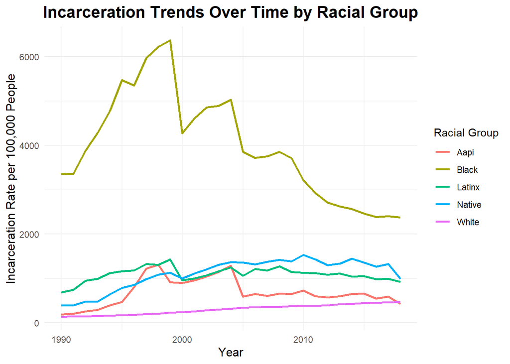

### Variable Comparison Chart

This chart was included to show how urbanicity tends to affect incarceration rates across every racial group. As more of America develops, it’s important to analyze how gentrification and urbanization affect ongoing trends of mass incarceration. Here I’ve taken the urbanicity variable from the dataset and plotted it as a continuous variable ranging from “rural” to “urban”. Looking at the average incarceration rates across the entirety of dataset a clear trend emerges, showing that with higher urbanicity, an area tends to incarcerate at lower rates in almost every ethnic group. Concerningly, the problem of Black Americans being incarcerated at higher rates still exists.

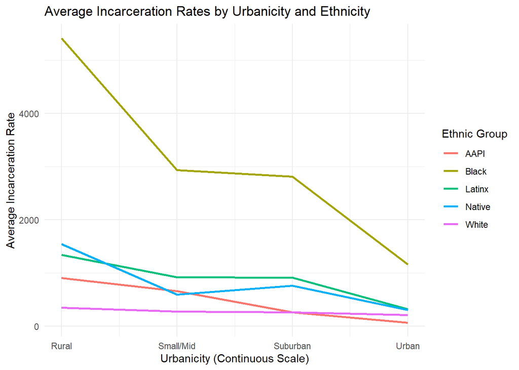

### Map

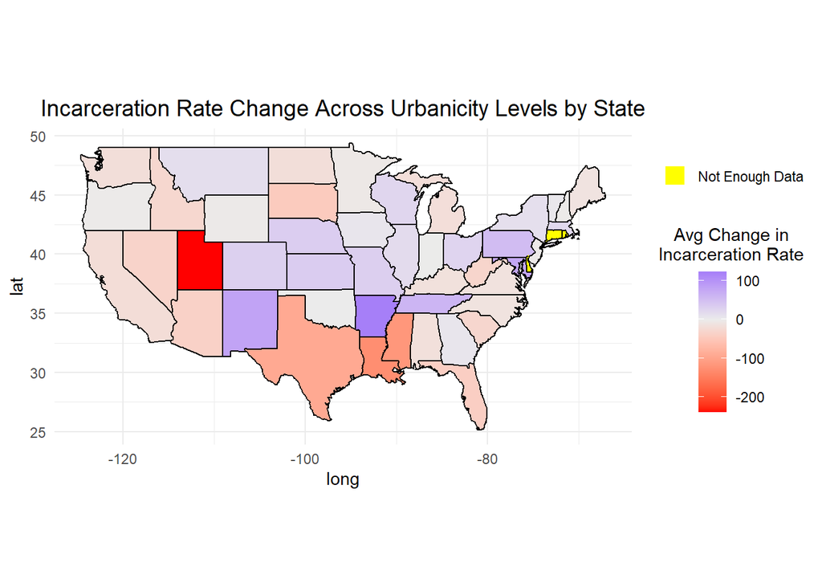